# Multiple Correspondence Analysis

Dataset respostas

This dataset contains 249 individuals and 19 variables.

### 1. Study of the outliers

The analysis of the graphs does not detect any outlier.

### 2. Inertia distribution

The inertia of the first dimensions shows if there are strong relationships between variables and suggests the number of dimensions that should be studied.

The first two dimensions of analyse express **27.84%** of the total dataset inertia ; that means that 27.84% of the individuals (or variables) cloud total variability is explained by the plane. This is a small percentage and the first plane just represents a part of the data variability. This value is greater than the reference value that equals **22.35%**, the variability explained by this plane is thus significant (the reference value is the 0.95-quantile of the inertia percentages distribution obtained by simulating 1945 data tables of equivalent size on the basis of a uniform distribution).

From these observations, it is interesting to consider the next dimensions which also express a high percentage of the total inertia.

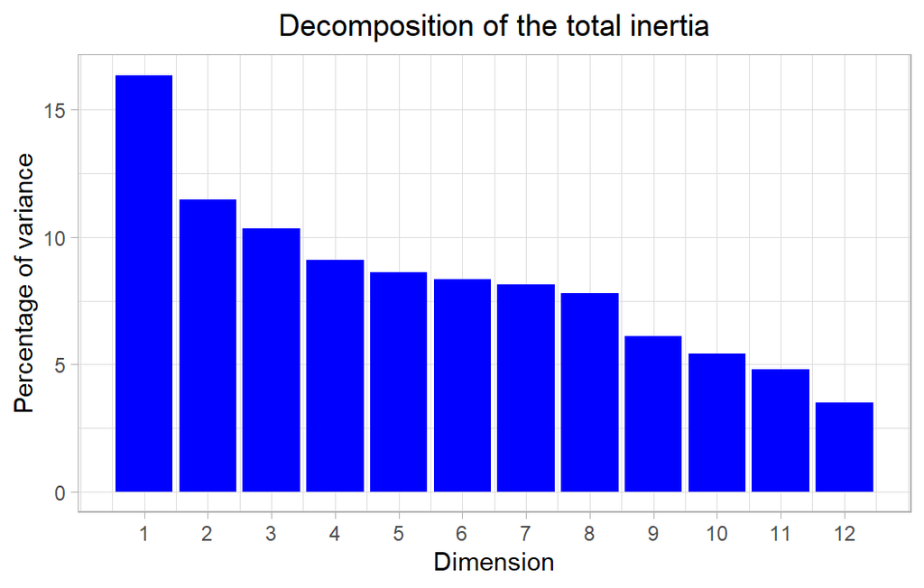

**Figure 2 - Decomposition of the total inertia**

An estimation of the right number of axis to interpret suggests to restrict the analysis to the description of the first 3 axis. These axis present an amount of inertia greater than those obtained by the 0.95-quantile of random distributions (38.18% against 32.21%). This observation suggests that only these axis are carrying a real information. As a consequence, the description will stand to these axis.

### 3. Description of the plane 1:2

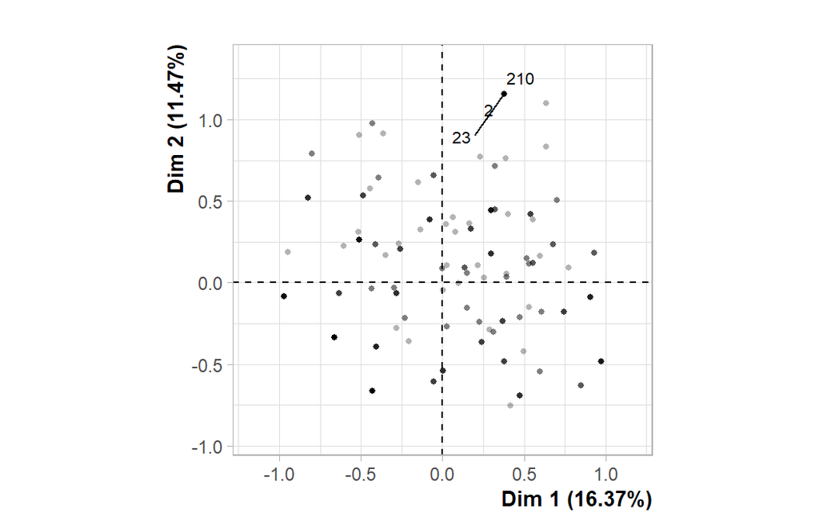

**Figure 3.1 - Individuals factor map (MCA)** *The labeled individuals are those with the higher contribution to the plane construction.*

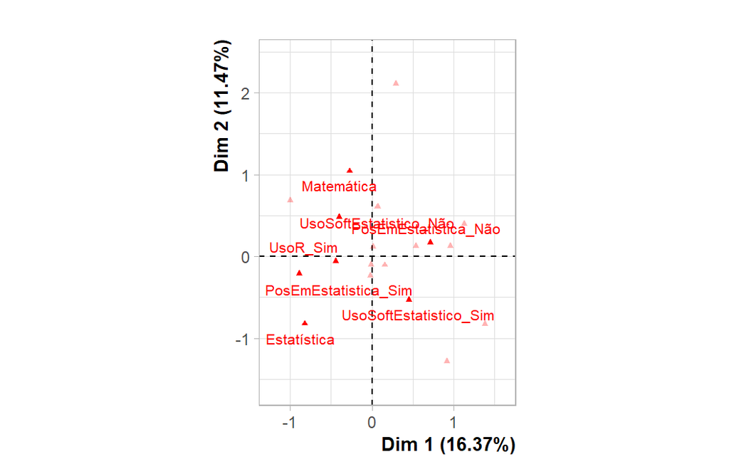

**Figure 3.2 - Variables factor map (MCA)** *The labeled variables are those the best shown on the plane.*

The **dimension 1** opposes individuals such as *2*, *23* and *210* (to the right of the graph, characterized by a strongly positive coordinate on the axis) to individuals characterized by a strongly negative coordinate on the axis (to the left of the graph).

The group in which the individuals *2*, *23* and *210* stand (characterized by a positive coordinate on the axis) is sharing :

- high frequency for the factors *Pós.Graduação=PosEmEstatistica_Não*, *UsoSoftEducacional=UsoSoftEducacional_Sim*, *Graduação=Matemática*, *UsoLingProgramacao=UsoLingProgramacao_Sim*, *UsoR=UsoR_Não* and *UsoSoftEstatistico=UsoSoftEstatistico_Não* (factors are sorted from the most common).
- low frequency for the factors *Pós.Graduação=PosEmEstatistica_Sim*, *UsoSoftEducacional=UsoSoftEducacional_Não*, *Graduação=Estatística*, *UsoLingProgramacao=UsoLingProgramacao_Não*, *UsoR=UsoR_Sim* and *UsoSoftEstatistico=UsoSoftEstatistico_Sim* (factors are sorted from the rarest).

The group 2 (characterized by a positive coordinate on the axis) is sharing :

- high frequency for the factors *UsoR=UsoR_Não*, *Pós.Graduação=PosEmEstatistica_Não*, *UsoSoftEstatistico=UsoSoftEstatistico_Sim*, *Graduação=Outra*, *Graduação=Saúde*, *Graduação=Engenharia*, *Graduação=Biologia* and *UsoSoftPlanilha=UsoSoftPlanilha_Sim* (factors are sorted from the most common).
- low frequency for the factors *UsoR=UsoR_Sim*, *Pós.Graduação=PosEmEstatistica_Sim*, *UsoSoftEstatistico=UsoSoftEstatistico_Não*, *Graduação=Estatística*, *Graduação=Matemática* and *UsoSoftPlanilha=UsoSoftPlanilha_Não* (factors are sorted from the rarest).

The group 3 (characterized by a negative coordinate on the axis) is sharing :

- high frequency for the factors *Graduação=Estatística*, *UsoSoftEstatistico=UsoSoftEstatistico_Não*, *Pós.Graduação=PosEmEstatistica_Sim*, *UsoR=UsoR_Sim* and *UsoSoftPlanilha=UsoSoftPlanilha_Não* (factors are sorted from the most common).
- low frequency for the factors *UsoSoftEstatistico=UsoSoftEstatistico_Sim*, *Pós.Graduação=PosEmEstatistica_Não*, *UsoR=UsoR_Não*, *Graduação=Matemática*, *UsoSoftPlanilha=UsoSoftPlanilha_Sim* and *Graduação=Outra* (factors are sorted from the rarest).

The group 4 (characterized by a negative coordinate on the axis) is sharing :

- high frequency for the factors *Graduação=Matemática*, *UsoSoftEstatistico=UsoSoftEstatistico_Não*, *UsoR=UsoR_Sim*, *UsoSoftPlanilha=UsoSoftPlanilha_Não* and *Pós.Graduação=PosEmEstatistica_Sim* (factors are sorted from the most common).
- low frequency for the factors *Graduação=Estatística*, *UsoSoftEstatistico=UsoSoftEstatistico_Sim*, *UsoR=UsoR_Não*, *UsoSoftPlanilha=UsoSoftPlanilha_Sim* and *Pós.Graduação=PosEmEstatistica_Não* (factors are sorted from the rarest).

The **dimension 2** opposes individuals such as *2*, *23* and *210* (to the top of the graph, characterized by a strongly positive coordinate on the axis) to individuals characterized by a strongly negative coordinate on the axis (to the bottom of the graph).

The group 1 (characterized by a positive coordinate on the axis) is sharing :

- high frequency for the factors *Graduação=Matemática*, *UsoSoftEstatistico=UsoSoftEstatistico_Não*, *UsoR=UsoR_Sim*, *UsoSoftPlanilha=UsoSoftPlanilha_Não* and *Pós.Graduação=PosEmEstatistica_Sim* (factors are sorted from the most common).
- low frequency for the factors *Graduação=Estatística*, *UsoSoftEstatistico=UsoSoftEstatistico_Sim*, *UsoR=UsoR_Não*, *UsoSoftPlanilha=UsoSoftPlanilha_Sim* and *Pós.Graduação=PosEmEstatistica_Não* (factors are sorted from the rarest).

The group in which the individuals *2*, *23* and *210* stand (characterized by a positive coordinate on the axis) is sharing :

- high frequency for the factors *Pós.Graduação=PosEmEstatistica_Não*, *UsoSoftEducacional=UsoSoftEducacional_Sim*, *Graduação=Matemática*, *UsoLingProgramacao=UsoLingProgramacao_Sim*, *UsoR=UsoR_Não* and *UsoSoftEstatistico=UsoSoftEstatistico_Não* (factors are sorted from the most common).
- low frequency for the factors *Pós.Graduação=PosEmEstatistica_Sim*, *UsoSoftEducacional=UsoSoftEducacional_Não*, *Graduação=Estatística*, *UsoLingProgramacao=UsoLingProgramacao_Não*, *UsoR=UsoR_Sim* and *UsoSoftEstatistico=UsoSoftEstatistico_Sim* (factors are sorted from the rarest).

The group 3 (characterized by a negative coordinate on the axis) is sharing :

- high frequency for the factors *Graduação=Estatística*, *UsoSoftEstatistico=UsoSoftEstatistico_Não*, *Pós.Graduação=PosEmEstatistica_Sim*, *UsoR=UsoR_Sim* and *UsoSoftPlanilha=UsoSoftPlanilha_Não* (factors are sorted from the most common).
- low frequency for the factors *UsoSoftEstatistico=UsoSoftEstatistico_Sim*, *Pós.Graduação=PosEmEstatistica_Não*, *UsoR=UsoR_Não*, *Graduação=Matemática*, *UsoSoftPlanilha=UsoSoftPlanilha_Sim* and *Graduação=Outra* (factors are sorted from the rarest).

The group 4 (characterized by a negative coordinate on the axis) is sharing :

- high frequency for the factors *UsoSoftEstatistico=UsoSoftEstatistico_Sim*, *Graduação=Estatística*, *UsoLingProgramacao=UsoLingProgramacao_Não* and *UsoSoftPlanilha=UsoSoftPlanilha_Sim* (factors are sorted from the most common).
- low frequency for the factors *UsoSoftEstatistico=UsoSoftEstatistico_Não*, *Graduação=Matemática*, *UsoLingProgramacao=UsoLingProgramacao_Sim*, *UsoSoftPlanilha=UsoSoftPlanilha_Não* and *Graduação=Outra* (factors are sorted from the rarest).

The group 5 (characterized by a negative coordinate on the axis) is sharing :

- high frequency for the factors *UsoR=UsoR_Não*, *Pós.Graduação=PosEmEstatistica_Não*, *UsoSoftEstatistico=UsoSoftEstatistico_Sim*, *Graduação=Outra*, *Graduação=Saúde*, *Graduação=Engenharia*, *Graduação=Biologia* and *UsoSoftPlanilha=UsoSoftPlanilha_Sim* (factors are sorted from the most common).
- low frequency for the factors *UsoR=UsoR_Sim*, *Pós.Graduação=PosEmEstatistica_Sim*, *UsoSoftEstatistico=UsoSoftEstatistico_Não*, *Graduação=Estatística*, *Graduação=Matemática* and *UsoSoftPlanilha=UsoSoftPlanilha_Não* (factors are sorted from the rarest).

### 4. Description of the dimension 3

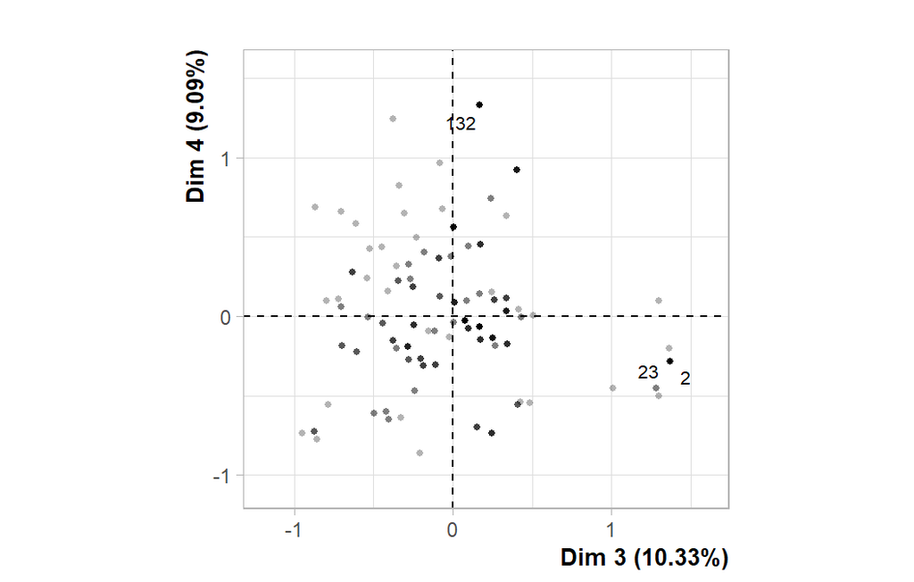

**Figure 4.1 - Individuals factor map (MCA)** *The labeled individuals are those with the higher contribution to the plane construction.*

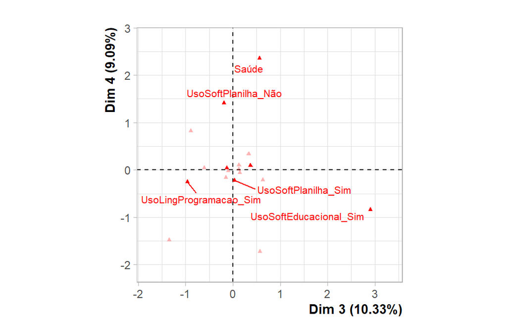

**Figure 4.2 - Variables factor map (MCA)** *The labeled variables are those the best shown on the plane.*

The **dimension 3** opposes individuals such as *2* and *23* (to the right of the graph, characterized by a strongly positive coordinate on the axis) to individuals characterized by a strongly negative coordinate on the axis (to the left of the graph).

The group in which the individuals *2* and *23* stand (characterized by a positive coordinate on the axis) is sharing :

- high frequency for the factors *Graduação=Matemática*, *UsoLingProgramacao=UsoLingProgramacao_Não*, *Graduação=Biologia*, *UsoSoftEducacional=UsoSoftEducacional_Sim*, *UsoSoftPlanilha=UsoSoftPlanilha_Sim* and *UsoSoftEstatistico=UsoSoftEstatistico_Sim* (factors are sorted from the most common).
- low frequency for the factors *UsoLingProgramacao=UsoLingProgramacao_Sim*, *UsoSoftEducacional=UsoSoftEducacional_Não*, *UsoSoftPlanilha=UsoSoftPlanilha_Não*, *Graduação=Economia*, *Graduação=Engenharia*, *Graduação=Estatística*, *Graduação=Saúde*, *UsoSoftEstatistico=UsoSoftEstatistico_Não* and *Graduação=Outra* (factors are sorted from the rarest).

The group 2 (characterized by a negative coordinate on the axis) is sharing :

- high frequency for the factors *UsoLingProgramacao=UsoLingProgramacao_Sim*, *Graduação=Economia*, *UsoSoftPlanilha=UsoSoftPlanilha_Sim*, *Graduação=Outra*, *UsoSoftEducacional=UsoSoftEducacional_Não* and *Graduação=Engenharia* (factors are sorted from the most common).
- low frequency for the factors *UsoLingProgramacao=UsoLingProgramacao_Não*, *UsoSoftPlanilha=UsoSoftPlanilha_Não*, *Graduação=Matemática*, *Graduação=Saúde*, *UsoSoftEducacional=UsoSoftEducacional_Sim* and *Graduação=Biologia* (factors are sorted from the rarest).